# Quality of Red Wines Exploration by Clement viel

## Univariate Plots Section

Dimensions of the dataset:

```
## [1] 1599   13
```

List of variables:

```
##  [1] "X"                    "fixed.acidity"        "volatile.acidity"
##  [4] "citric.acid"          "residual.sugar"       "chlorides"
##  [7] "free.sulfur.dioxide"  "total.sulfur.dioxide" "density"
## [10] "pH"                   "sulphates"            "alcohol"
## [13] "quality"
```

Overview:

```
## 'data.frame':    1599 obs. of  13 variables:
##  $ X                   : int  1 2 3 4 5 6 7 8 9 10 ...
##  $ fixed.acidity       : num  7.4 7.8 7.8 11.2 7.4 7.4 7.9 7.3 7.8 7.5 ...
##  $ volatile.acidity    : num  0.7 0.88 0.76 0.28 0.7 0.66 0.6 0.65 0.58 0.5 ...
##  $ citric.acid         : num  0 0 0.04 0.56 0 0 0.06 0 0.02 0.36 ...
##  $ residual.sugar      : num  1.9 2.6 2.3 1.9 1.9 1.8 1.6 1.2 2 6.1 ...
##  $ chlorides           : num  0.076 0.098 0.092 0.075 0.076 0.075 0.069 0.065 0.073 0.071 ...
##  $ free.sulfur.dioxide : num  11 25 15 17 11 13 15 15 9 17 ...
##  $ total.sulfur.dioxide: num  34 67 54 60 34 40 59 21 18 102 ...
##  $ density             : num  0.998 0.997 0.997 0.998 0.998 ...
##  $ pH                  : num  3.51 3.2 3.26 3.16 3.51 3.51 3.3 3.39 3.36 3.35 ...
##  $ sulphates           : num  0.56 0.68 0.65 0.58 0.56 0.56 0.46 0.47 0.57 0.8 ...
##  $ alcohol             : num  9.4 9.8 9.8 9.8 9.4 9.4 9.4 10 9.5 10.5 ...
##  $ quality             : int  5 5 5 6 5 5 5 7 7 5 ...
```

Summary:

```
##  fixed.acidity   volatile.acidity  citric.acid    residual.sugar
##  Min.   : 4.60   Min.   :0.1200   Min.   :0.000   Min.   : 0.900
##  1st Qu.: 7.10   1st Qu.:0.3900   1st Qu.:0.090   1st Qu.: 1.900
##  Median : 7.90   Median :0.5200   Median :0.260   Median : 2.200
##  Mean   : 8.32   Mean   :0.5278   Mean   :0.271   Mean   : 2.539
##  3rd Qu.: 9.20   3rd Qu.:0.6400   3rd Qu.:0.420   3rd Qu.: 2.600
##  Max.   :15.90   Max.   :1.5800   Max.   :1.000   Max.   :15.500
##    chlorides       free.sulfur.dioxide total.sulfur.dioxide
##  Min.   :0.01200   Min.   : 1.00       Min.   :  6.00
##  1st Qu.:0.07000   1st Qu.: 7.00       1st Qu.: 22.00
##  Median :0.07900   Median :14.00       Median : 38.00
##  Mean   :0.08747   Mean   :15.87       Mean   : 46.47
##  3rd Qu.:0.09000   3rd Qu.:21.00       3rd Qu.: 62.00
##  Max.   :0.61100   Max.   :72.00       Max.   :289.00
##     density             pH          sulphates         alcohol
##  Min.   :0.9901   Min.   :2.740   Min.   :0.3300   Min.   : 8.40
##  1st Qu.:0.9956   1st Qu.:3.210   1st Qu.:0.5500   1st Qu.: 9.50
##  Median :0.9968   Median :3.310   Median :0.6200   Median :10.20
##  Mean   :0.9967   Mean   :3.311   Mean   :0.6581   Mean   :10.42
##  3rd Qu.:0.9978   3rd Qu.:3.400   3rd Qu.:0.7300   3rd Qu.:11.10
##  Max.   :1.0037   Max.   :4.010   Max.   :2.0000   Max.   :14.90
##     quality
##  Min.   :3.000
##  1st Qu.:5.000
##  Median :6.000
##  Mean   :5.636
##  3rd Qu.:6.000
##  Max.   :8.000
```

Maximum values are oddly very high for most of the attributes (all but ph, alcohol and quality), which suggests the presence of outliers (either wrong measures or uncommon wines). Density takes values in a very small range ([0.99, 1.004]) like 75% of the chlorides ([0,0.1]) and 75% of the volatile.acidity ([0.1,0.64]). Median alcohol level is 10.20% while median quality is 6 with Maximum 8.

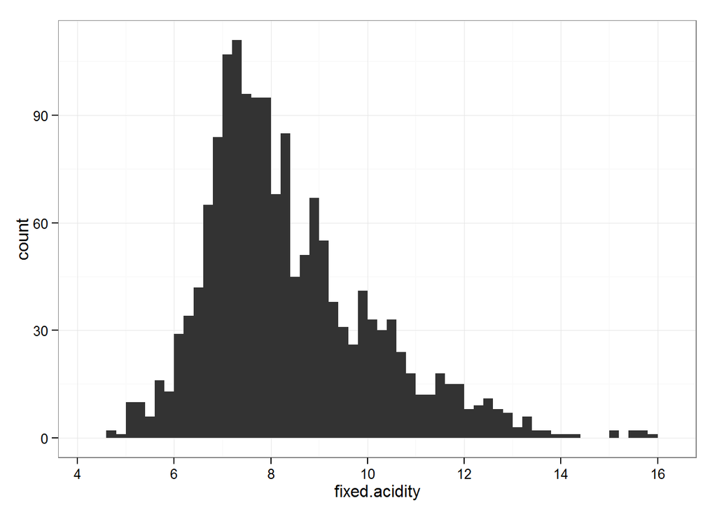

Taken apart the drops on the right slopes, the data seems to follow a normal distribution (centered in 7.5). It is slightly right skewed though. Most of the values are contained within [7, 9.2] interval.

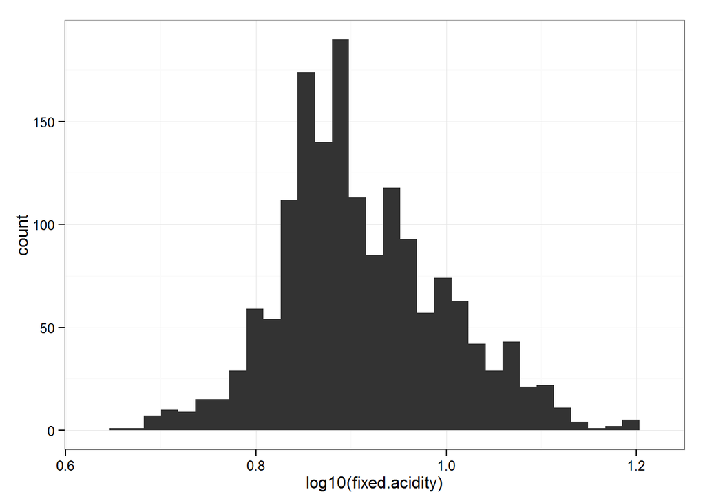

Applying a log transformation, recenter the distribution a bit but nothing very significant.

```
##    Min. 1st Qu.  Median    Mean 3rd Qu.    Max.
##    4.60    7.10    7.90    8.32    9.20   15.90
```

```
##     X fixed.acidity quality
## 1 443          15.6       7
## 2 555          15.5       5
## 3 556          15.5       5
## 4 558          15.6       5
## 5 653          15.9       5
```

5 records stand apart with fixed.acidity above 15. At this point of the analysis, I can’t really say more about them (even their quality score isn’t that good).

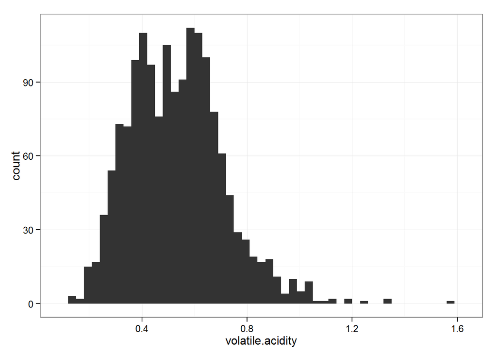

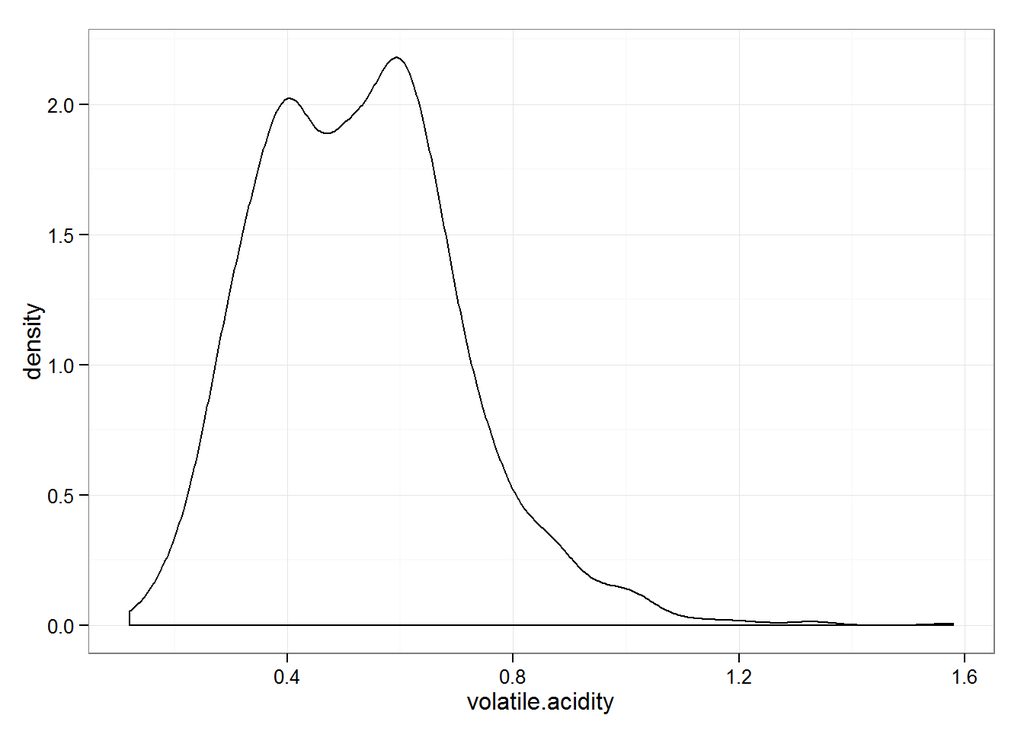

Even though, volatile.acidity looks like a normal distribution, the density function clearly shows two peaks at 0.4 and 0.6 with no valid reason. I am therefore wondering how these two peaks are related to the Quality. Few outliers also stands between 1.2 and 1.6.

```
##      X volatile.acidity quality
## 1  127             1.33       5
## 2  128             1.33       5
## 3  673             1.24       5
## 4 1300             1.58       3
```

These outlier don’t match the ones previously found in fixed.acidity.

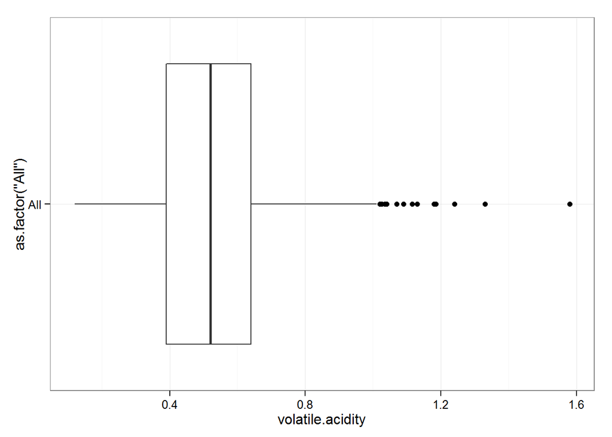

```
##    Min. 1st Qu.  Median    Mean 3rd Qu.    Max.
##  0.1200  0.3900  0.5200  0.5278  0.6400  1.5800
```

```
## [1] 0.1790597
```

The data stick very closed to the mean as the small value of the standard deviation suggests.

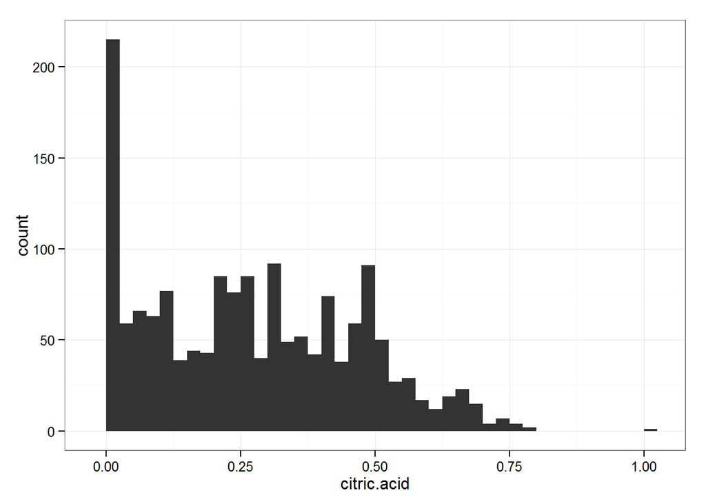

```
##    Min. 1st Qu.  Median    Mean 3rd Qu.    Max.
##   0.000   0.090   0.260   0.271   0.420   1.000
```

```
## [1] 132
```

The documentation tells us that citric.acid are “found in small quantities”, hence these records showing quantity 0 were probably too small to be measured correctly rather than actual 0. Still, I shall consider filtering them out for further analyses.

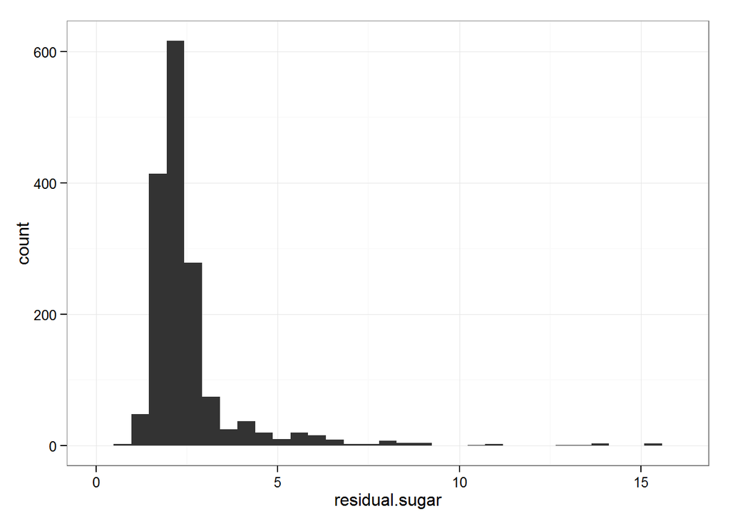

```
##    Min. 1st Qu.  Median    Mean 3rd Qu.    Max.
##   0.900   1.900   2.200   2.539   2.600  15.500
```

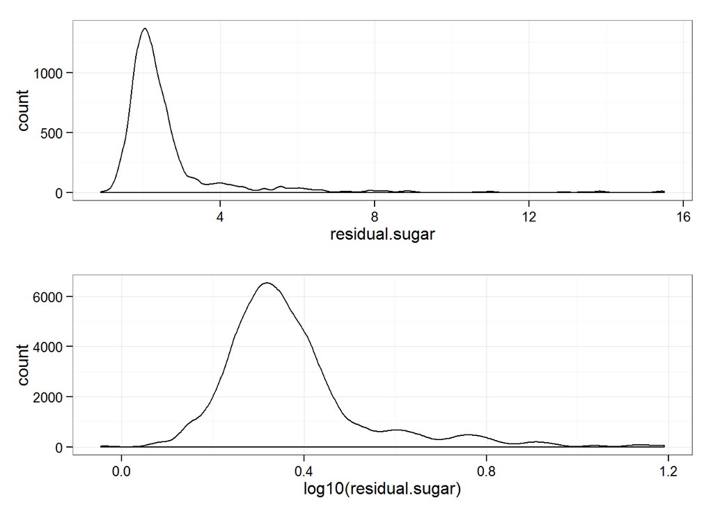

The distribution of the residual.sugar takes 75 % of its values between 0.9 and 2.6 with a long tail reaching 15 (too numerous to be classified as outliers). A Log10 transformation provides a bit of improvements and makes the distribution looking more like a bell-shaped normal distribution. That’s definitely something I will want to experiment later on to measure the impact on quality.

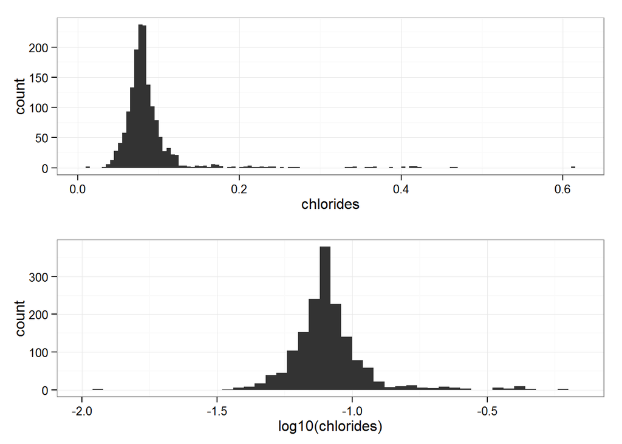

```
##    Min. 1st Qu.  Median    Mean 3rd Qu.    Max.
## 0.01200 0.07000 0.07900 0.08747 0.09000 0.61100
```

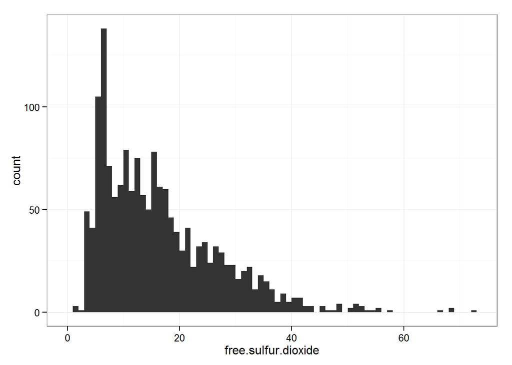

```
##    Min. 1st Qu.  Median    Mean 3rd Qu.    Max.
##    1.00    7.00   14.00   15.87   21.00   72.00
```

```
## Source: local data frame [2 x 2]
##
##   free.sulfur.dioxide   n
## 1                   6 138
## 2                   5 104
```

According to the documentation, “free SO2 prevents microbial growth and the oxidation of wine”. I therefore wonder if the wines with free SO2 = 5 and 6 (top 2 highest count) could be associated to better quality wines or the opposite.

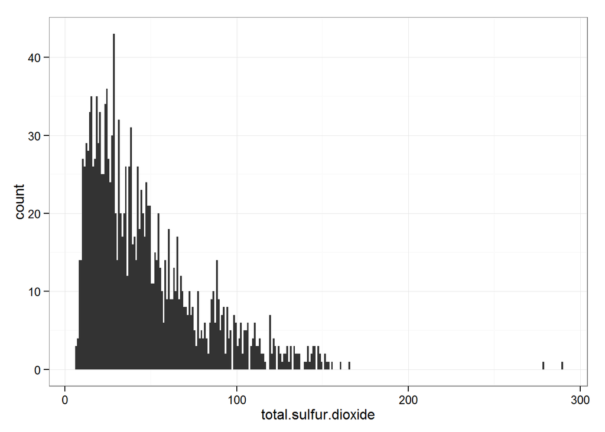

```
##    Min. 1st Qu.  Median    Mean 3rd Qu.    Max.
##    6.00   22.00   38.00   46.47   62.00  289.00
```

Total.sulfure.dioxide is defined as “the amount of free and bound forms of S02”, that is, includes the free.sulfure.dioxide variable. Hence, it isn’t surprising that the shape of the two distributions are very similar and total.sulfure.dioxide takes higher values. Besides, the documentation gives us a hint about the relationship between sulfur and quality: “over 50 ppm, SO2 becomes evident in the nose and taste of wine” . This hypothesis will need to be confirmed though.

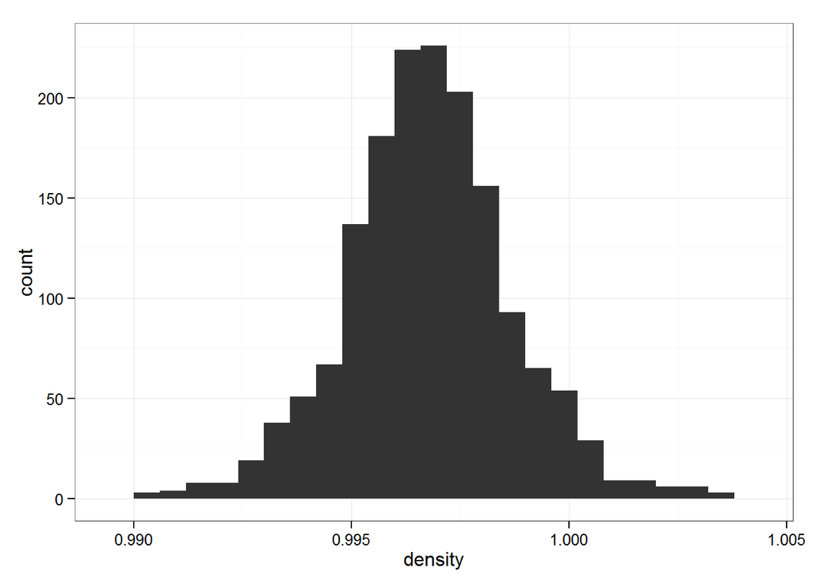

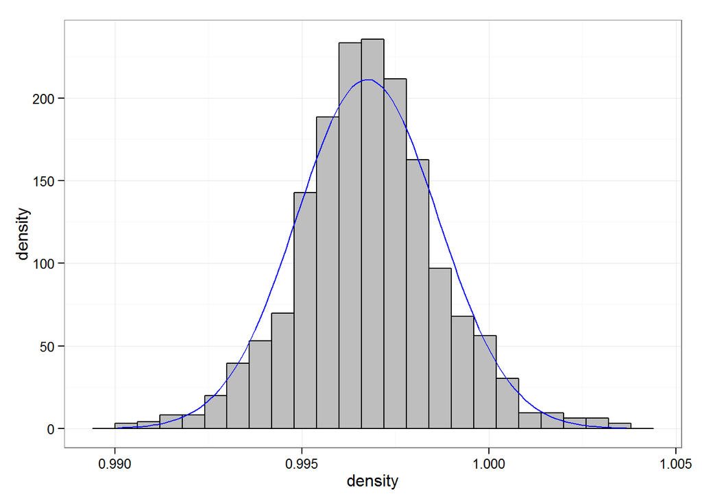

```
##    Min. 1st Qu.  Median    Mean 3rd Qu.    Max.
##  0.9901  0.9956  0.9968  0.9967  0.9978  1.0040
```

```
## [1] 0.001887334
```

As one can see, the density is evenly distributed around its mean and fits pretty well a normal distribution of mean = 0.9967467 and standard deviation 0.0018873. The range of values is however very narrow ([0.99007, 1.00369]). The documentation tell us that density is very depending on alcohol and sugar variable. So this variable might not bring much additional information in determining the quality of a wine. Again, an assumption to be confirmed.

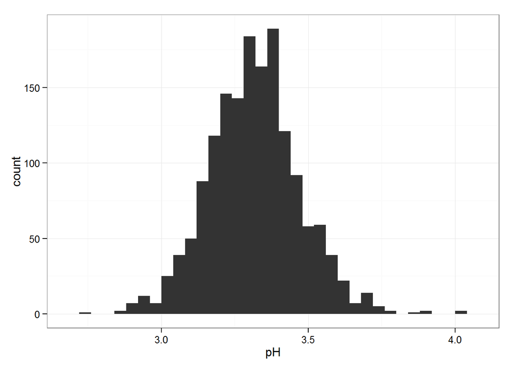

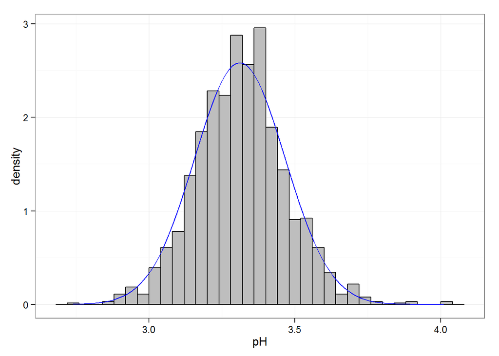

```
##    Min. 1st Qu.  Median    Mean 3rd Qu.    Max.
##   2.740   3.210   3.310   3.311   3.400   4.010
```

```
## [1] 0.1543865
```

Like density, pH perfectly fits a normal distribution of 3.3111132 an standard deviation 0.1543865. Ph of 7 is known to be the point of reference (neutral). All the records having a pH below 4.01, it is obvious that wine, by definition, is always acidic. I am therefore wondering how far (from 7 toward 0) a wine can be acidic, that is, whether there is any tipping point from which the quality starts decreasing.

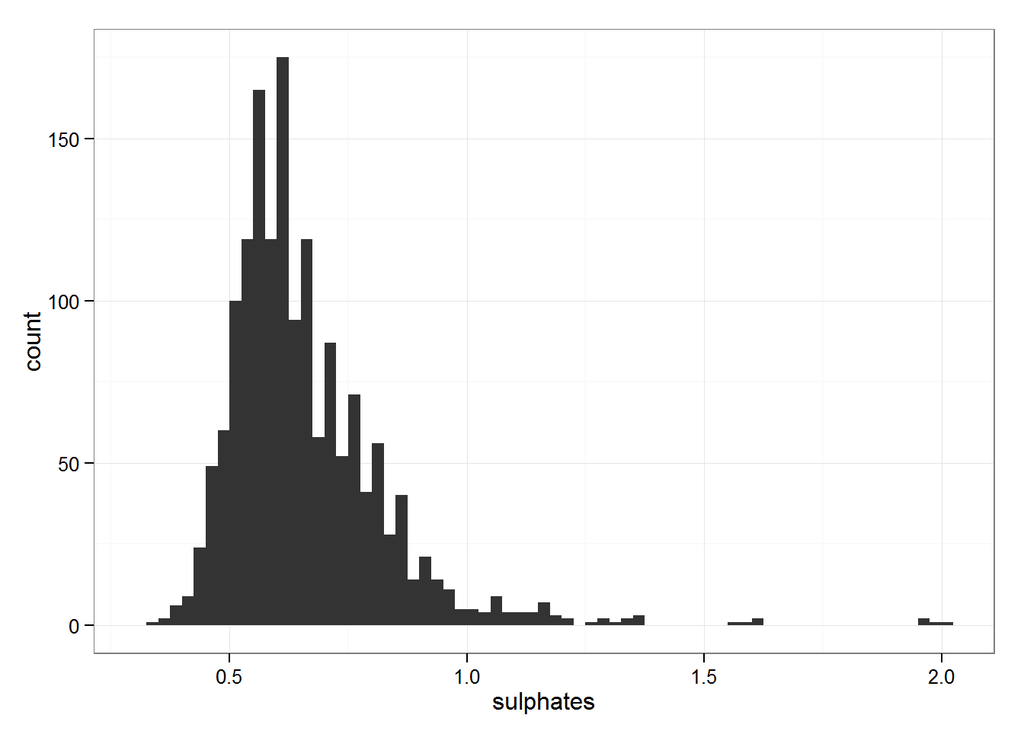

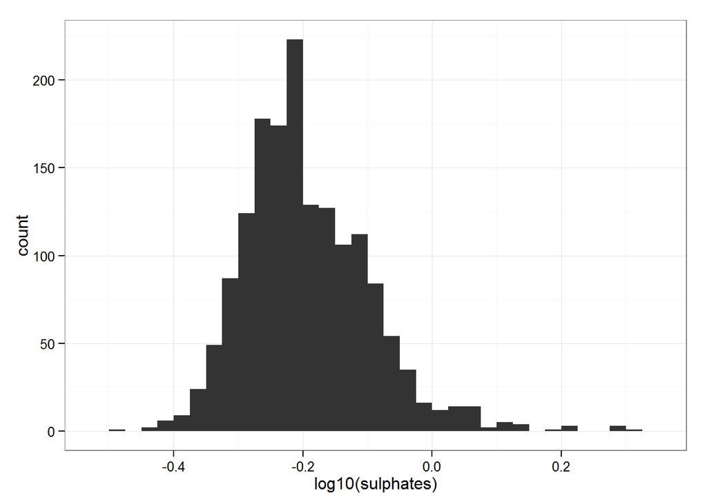

```
##    Min. 1st Qu.  Median    Mean 3rd Qu.    Max.
##  0.3300  0.5500  0.6200  0.6581  0.7300  2.0000
```

```
## [1] 0.169507
```

```
##     X sulphates quality
## 1  14      1.56       5
## 2  87      1.95       6
## 3  92      1.95       6
## 4  93      1.98       5
## 5 152      2.00       4
## 6 170      1.59       5
## 7 227      1.61       6
## 8 724      1.62       5
```

Sulphate variable benefits a log10 transformation, as it takes 75% of its values between [0.33, 0.73], (i.e. right tailed distribution). I can also identify a couple of outliers standing above 1.5.

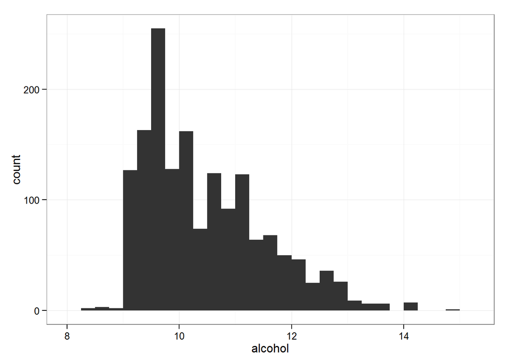

```
##    Min. 1st Qu.  Median    Mean 3rd Qu.    Max.
##    8.40    9.50   10.20   10.42   11.10   14.90
```

Alcohol distribution is very skewed: 50% od the data are contained within [9.5, 11.1] while the range of possible values goes accross 6.5 unit (i.e. percent) of alcohol.

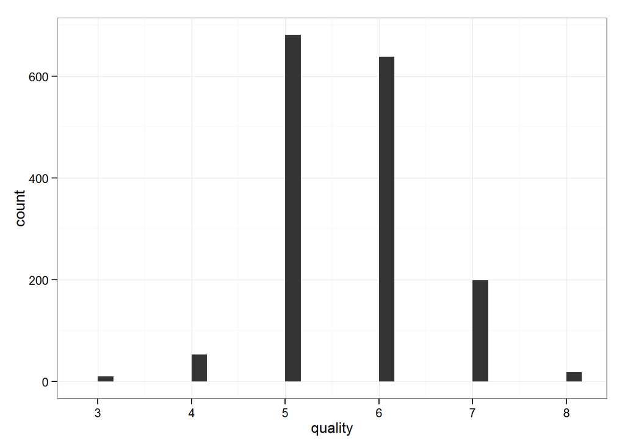

```
## [1] "3" "4" "5" "6" "7" "8"
```

```
##    Min. 1st Qu.  Median    Mean 3rd Qu.    Max.
##   3.000   5.000   6.000   5.636   6.000   8.000
```

Quality variable should be seen more as a grading rather than a score. Thus, it could be interesting to convert it into a factor form. Quality classes *5* and *6* concentrate more than 80% of the values. That’s because the “quality classes are unbalanced”, with more normal wines than excellent / poor ones. None take values in *1*, *2*, *9* or *10*. On a scale from 0 to 10, I was expected a symmetric distribution centered around 5.

## Univariate Analysis

### What is the structure of your dataset?

There are 1599 wines in the dataset with 11 features (fixed.acidity, volatile.acidity, citric.acid, residual.sugar, chlorides, free.sulfur.dioxide, total.sulfur.dioxide, density, pH, sulphates and alcohol) + output (quality). Features are either physicochemical (inputs) or sensory (the output). Nothing about the location, grape variety, producers’ name… That would have been interesting pieces of information to cross-check with.

Other observations:

80% of the wines got assigned average quality score. None reached the very best (*9*, *10*) or very worst (*0*, *1*) quality classes.

Almost any feature includes outliers. They are however rarely the same, so no chance to filter them out easily. There might be linked to the “DNA” (i.e. unique combination of physicochemical features) of the wines.

### What is/are the main feature(s) of interest in your dataset?

Besides Quality (output), I believe alcohol, residual.sugar and pH are the main features of the dataset. Other features might help to better explain/predict it too. Others, like density, will most likely not, as there are covariates of other features.

### What other features in the dataset do you think will help support your investigation into your feature(s) of interest?

Volatile.acidity, total.sulfure.dioxide, and sulphates are other interesting features. From my understanding of the wine’s composition these two latter have significant impacts on its taste therefore will also contribute to its quality.

### Did you create any new variables from existing variables in the dataset?

I thought of calculating the SO2 (dixide) bound form from total.sulfur.dioxide - free.sulfur.dioxide, but refrained myself. At this point of the analysis, I am not even sure Total.sulfur.dioxide contributes significantly to the quality of the wine and are shaped the same way, so the subtraction of the two will most likely generate a third look-alike variable.

### Of the features you investigated, were there any unusual distributions? Did you perform any operations on the data to tidy, adjust, or change the form of the data? If so, why did you do this?

I log-transformed the right skewed fixed.acidity, residual.sugar and sulfates distributions. The transformed distribution were recentered around their mean and get closer to a normal distribution.

Whenever dealing with citric.acid, I think I will filter out all the 0 as they seem to be over representative (most likely because the instrument of measure wasn’t able to capture the very low levels of concentration).

The alcohol distribution looks very odd to me. There is a clear cut around 9 that no transformation can get rid of. I assume that below this threshold, the process of vinification (transforming grapes into wine) isn’t complete yet, thus not a “real” wine.

## Bivariate Plots Section

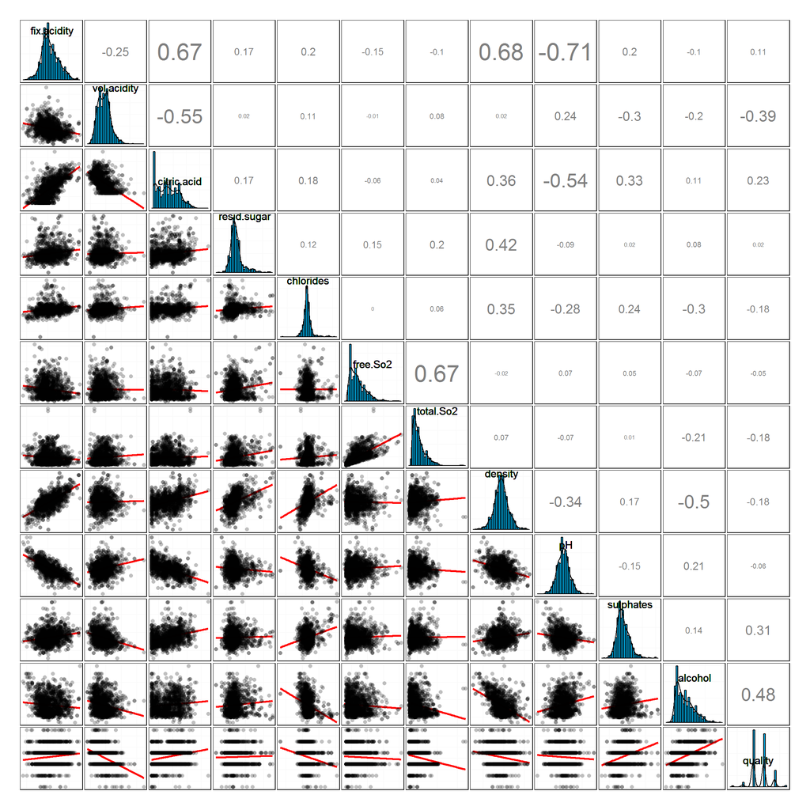

*Following the findings of the univariate analysis, fixed.acidity, residual.sugar, chlorides and sulphates variables were all log10 transformed in the hereinbefore correlation matrix.*

As assumed during univariate analysis, free.sulfure.dioxide is strongly correlated to total.sulfure.dioxide. Other point of interest, fixed.acidity is also strongly positively correlated to citric.acid, density and negatively to pH (which make sense as the lower the ph the more acid a solution is).

Quality, on another hand, doesn’t show such strong correlation. Some does exist but less significant. I will therefore start by analyzing quality against alcohol level (48%), volatile.acidity (-39%), sulphates (31%) and citric.acid (23%). I will alter complete with other variables that could contribute to explain/predict the quality score.

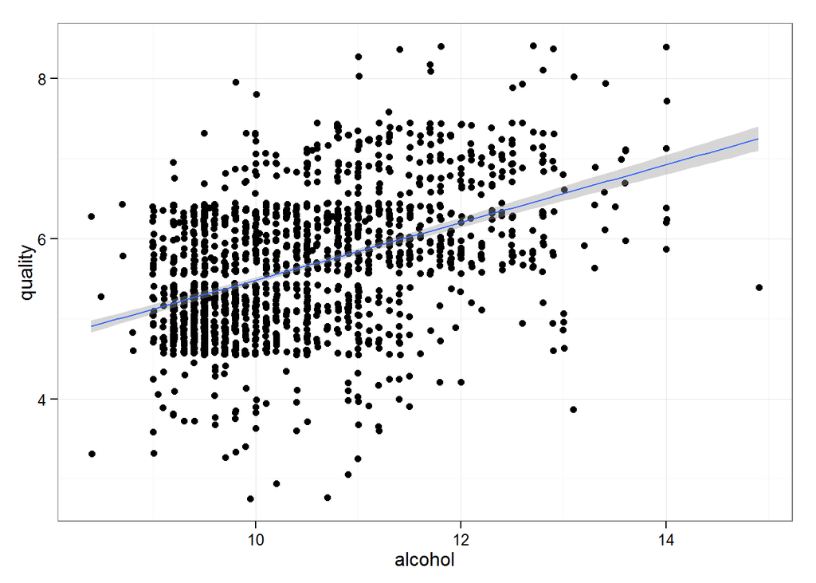

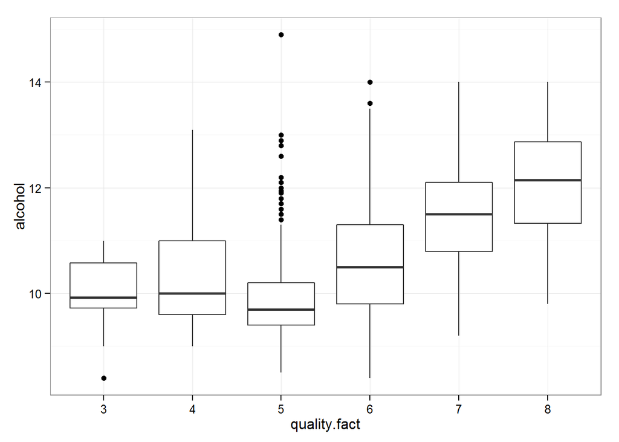

```
## [1] 0.5218858
```

From this plot, I can confirm that the more alcohol, the better a wine is. Up to certain point though.

Quality *3* and *4* are misleading because the number of points for this two categories are too low to hold them significant. Filtering these two classes from the dataset, can already help improving the correlation by 4 percent.

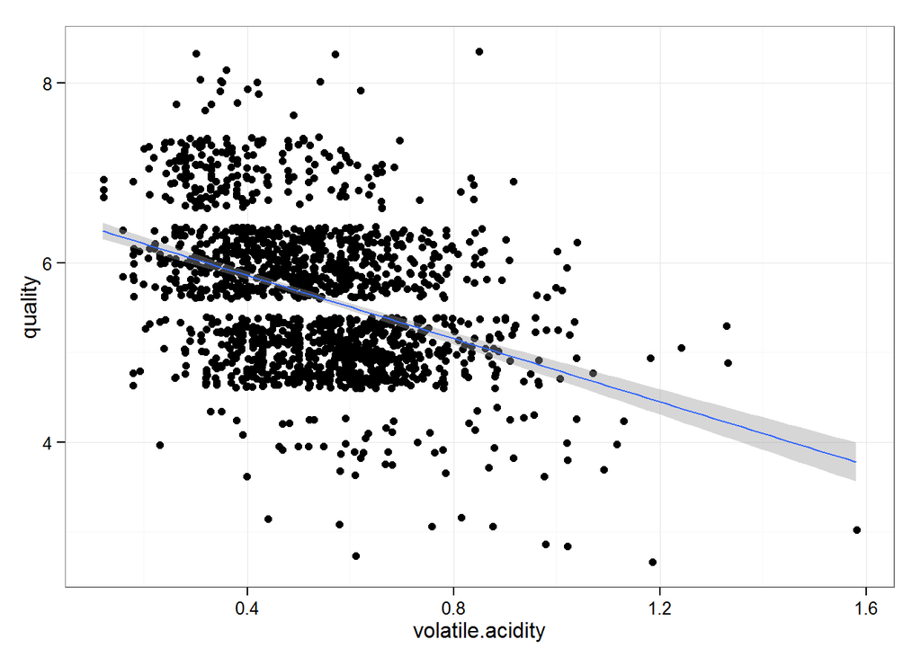

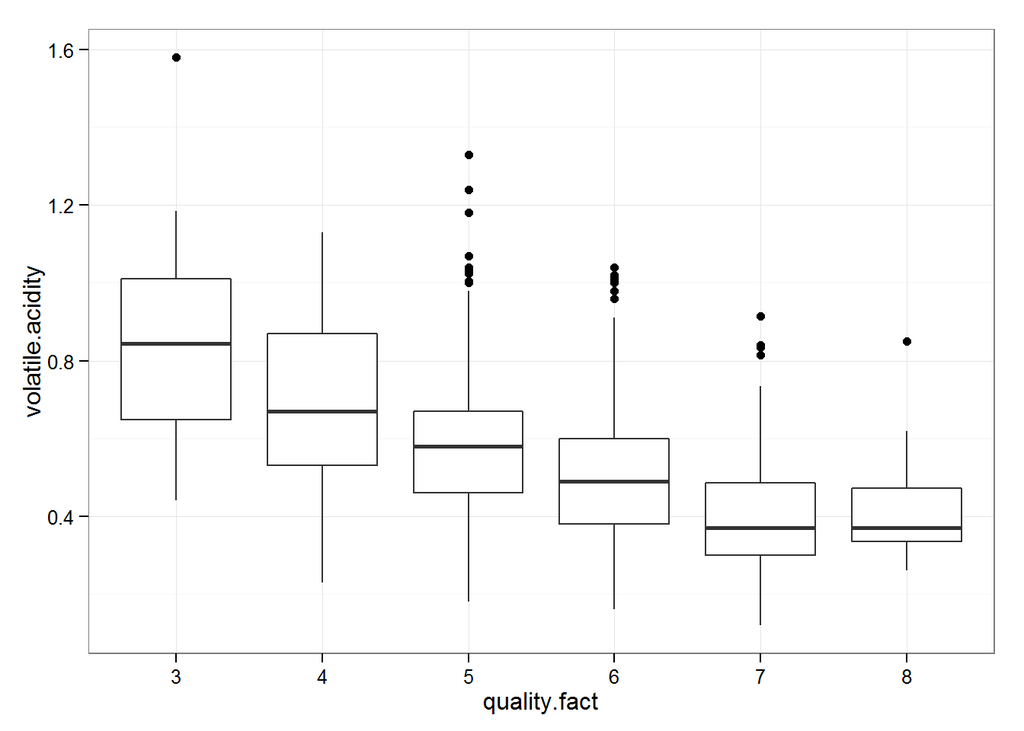

```
## rw$quality.fact: 3
##    Min. 1st Qu.  Median    Mean 3rd Qu.    Max.
##  0.4400  0.6475  0.8450  0.8845  1.0100  1.5800
## --------------------------------------------------------
## rw$quality.fact: 4
##    Min. 1st Qu.  Median    Mean 3rd Qu.    Max.
##   0.230   0.530   0.670   0.694   0.870   1.130
## --------------------------------------------------------
## rw$quality.fact: 5
##    Min. 1st Qu.  Median    Mean 3rd Qu.    Max.
##   0.180   0.460   0.580   0.577   0.670   1.330
## --------------------------------------------------------
## rw$quality.fact: 6
##    Min. 1st Qu.  Median    Mean 3rd Qu.    Max.
##  0.1600  0.3800  0.4900  0.4975  0.6000  1.0400
## --------------------------------------------------------
## rw$quality.fact: 7
##    Min. 1st Qu.  Median    Mean 3rd Qu.    Max.
##  0.1200  0.3000  0.3700  0.4039  0.4850  0.9150
## --------------------------------------------------------
## rw$quality.fact: 8
##    Min. 1st Qu.  Median    Mean 3rd Qu.    Max.
##  0.2600  0.3350  0.3700  0.4233  0.4725  0.8500
```

Quality *8* doesn’t obey the rule though. Its mean value is higher that quality *7*, even though the median is the same. Volatile.Acidity are less sparse for Quality *8* than *7* (which explains why its mean value is higher). The are two plausible reason: either the number of records with quality *8* is too small to be significant (like alcohol degree), thus disturbing the volatile.acidity on its right tail or the volatile.Acidity variable isn’t enough to make a clear distinction between two quality scores. Maybe both.

```
##
##   3   4   5   6   7   8
##  10  53 681 638 199  18
```

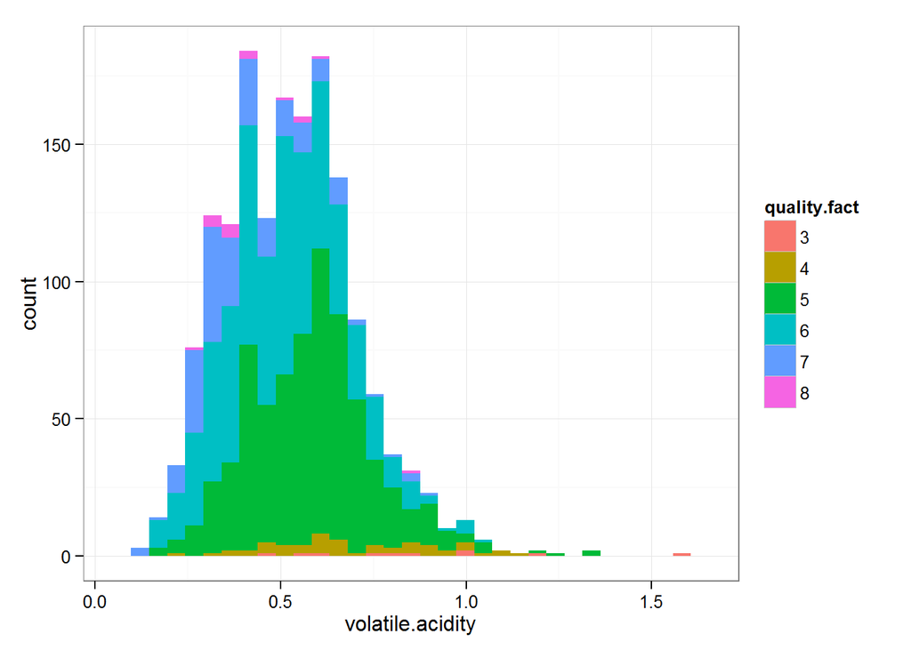

It seems that the behavior observed for quality *8* is actually a combination of the two previous assumptions. Only 18 records were assigned this class and, as the barchart suggests with up to 3 colors stacking above the same volatile.acidity values. This variable is therfore not enough to determine with certainty the quality scores.

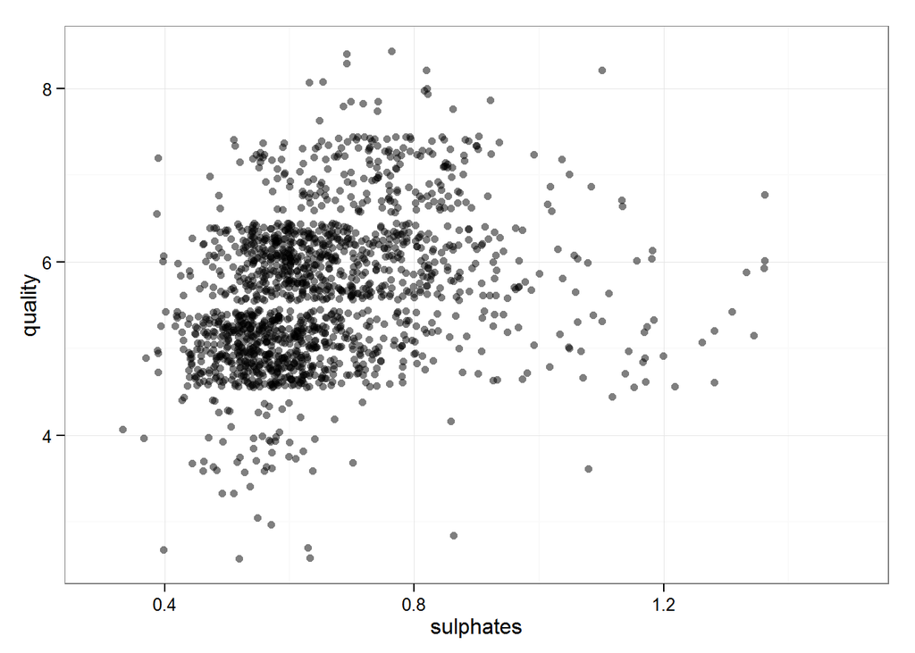

```
## [1] 0.2513971
```

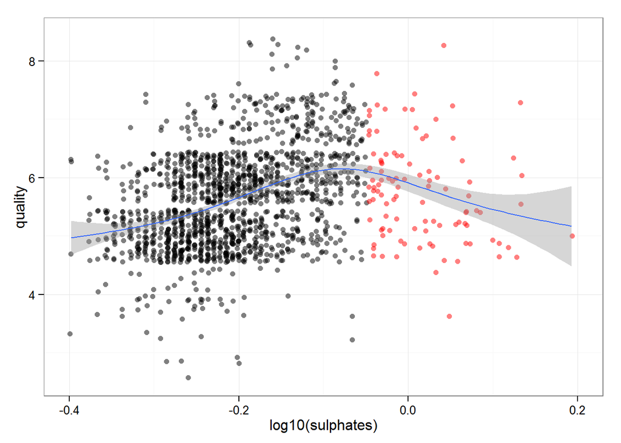

```
## [1] 0.3086419
```

```
## [1] 102
```

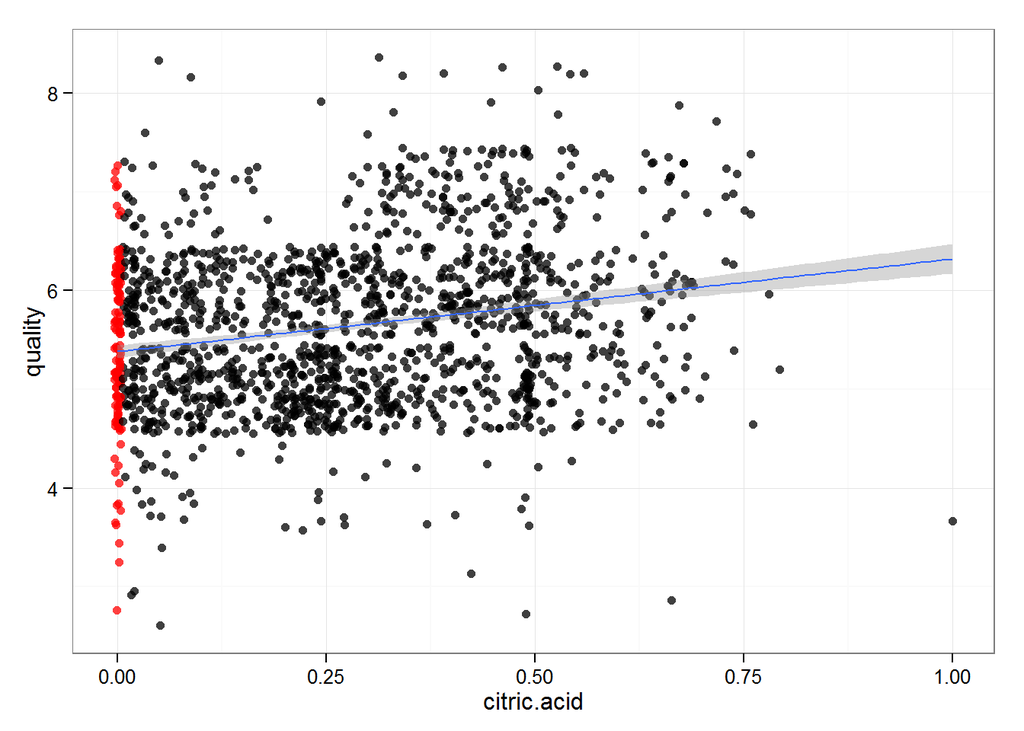

```
## (Intercept) citric.acid
##    5.381725    0.938452
```

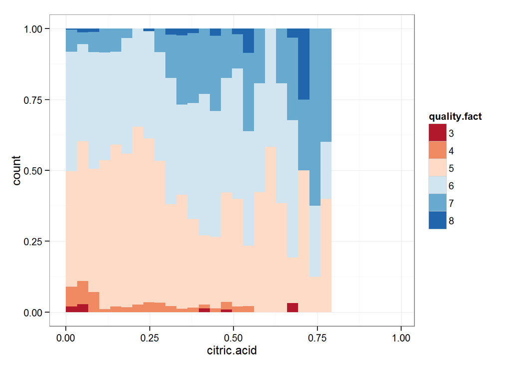

Citric.acid is also positively correlated to quality: the more concentration of citric.acid, the better quality a wine is. Nevertheless, it is clearly not enough to make a real difference between quality *5* and *6* (present in the same proportion). Note that quality *3* and *4* become less frequent with the citric.acid increasing and the opposite with quality *7* and *8*.

```
## quality.fact
##  3  4  5  6  7  8
##  3 10 57 54  8  0
```

```
## quality.fact
##    3    4    5    6    7    8
## 0.02 0.08 0.43 0.41 0.06 0.00
```

```
## quality.fact
##    3    4    5    6    7    8
## 0.00 0.03 0.43 0.40 0.13 0.01
```

Like described earlier in the univariate plot section, citric.acid = 0 is overcounted. This is made very obvious when plotting the data: the number of points (even jittered) stacks up in higher proportion above 0 axis value. This however hardly affects the degree of correlation between citric.acid and quality as the distribution of the quality classes doesn’t change much (in percent) with or without zero values.

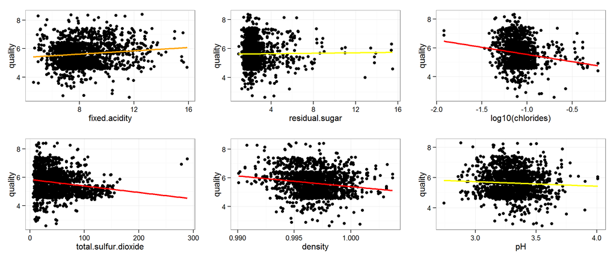

Amongst the variables left, only total.sulfur.dioxide, density and log10(chlorides) (all with correlation score above between 15 and 20%) show a semblance of trend. These three might be interesting to bring in the next Multivariate Plots Section to better explain the quality output. Others with correlation between 10 and 15% (orange trend lines) or below 10% (yellow lines) will hardly bring any additional information.

# Talk about some of the relationships you observed in this part of the investigation. How did the feature(s) of interest vary with other features in the dataset?

None of the variable correlates strongly with the quality output. However 4 of them stand out from others with a degree of correlation between 20% and 50%.

As alcohol degree increases, the quality increases. Sulphates and citric.acid are also positively correlated to the quality. The higher they are the better the quality is. Only the volatile.acidity negatively correlates to quality. The less is better.

One could think these 4 variable can be brought together to predict with accuracy the quality output. Reality is a bit more complex.

```
##
## Call:
## lm(formula = quality ~ alcohol + volatile.acidity + log10(sulphates) +
##     citric.acid, data = rw)
##
## Residuals:
##      Min       1Q   Median       3Q      Max
## -2.76173 -0.38005 -0.05619  0.45957  2.17555
##
## Coefficients:
##                  Estimate Std. Error t value Pr(>|t|)
## (Intercept)       3.44366    0.19582  17.586   <2e-16 ***
## alcohol           0.30305    0.01573  19.269   <2e-16 ***
## volatile.acidity -1.21687    0.11225 -10.841   <2e-16 ***
## log10(sulphates)  1.51794    0.18121   8.377   <2e-16 ***
## citric.acid      -0.11255    0.10302  -1.093    0.275
## ---
## Signif. codes:  0 '***' 0.001 '**' 0.01 '*' 0.05 '.' 0.1 ' ' 1
##
## Residual standard error: 0.6539 on 1594 degrees of freedom
## Multiple R-squared:  0.346,  Adjusted R-squared:  0.3443
## F-statistic: 210.8 on 4 and 1594 DF,  p-value: < 2.2e-16
```

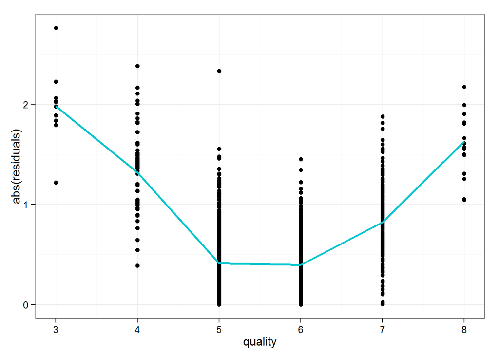

The linear model build upon these 4 variables doesn’t fit the actual Quality very well. Its R² value scores = 0.35. The residual distribution in U shape highlights, again, the fact that quality is unbalanced, with a lot of average quality (*5* and *6*). Hence, the residuals are below 0.5 for these two. It however raises drastically for better and poorer wines.

The model, as is, is therefore incomplete and not good enough to predict the whole range of quality. That’s why I will try to overcome with the multivariate analysis.

### What was the strongest relationship you found?

The strongest relationship found with quality was alcohol. And I can’t say it correlates very well because it only got scored 48%.